# Project: Neural Estate

**Teamleden:**

- Haben Sebhatu
- Chris de Nooijer
- Tom Spoler
- Ids Grunstra

## 1.2 Setup: Libraries importeren

```python
from google.colab import drive
drive.mount('/content/drive')
```

```python
import os
import random
import numpy as np
import matplotlib.pyplot as plt
import pandas as pd
import seaborn as sns
from PIL import Image
from sklearn.model_selection import train_test_split
from sklearn.preprocessing import StandardScaler

# TensorFlow en Keras
import tensorflow as tf
from tensorflow.keras.models import Sequential, Model  # pyright: ignore[reportMissingImports]
from tensorflow.keras.layers import (  # pyright: ignore[reportMissingImports]
    Input, Dense, Conv2D, MaxPooling2D,
    GlobalAveragePooling2D, Flatten,
    Dropout, BatchNormalization, Concatenate
)
from tensorflow.keras.optimizers import Adam  # pyright: ignore[reportMissingImports]
from tensorflow.keras.callbacks import EarlyStopping, ReduceLROnPlateau  # pyright: ignore[reportMissingImports]
from tensorflow.keras.preprocessing.image import (  # pyright: ignore[reportMissingImports]
    ImageDataGenerator, load_img, img_to_array
)
from tensorflow.keras.regularizers import l2  # pyright: ignore[reportMissingImports]
```

## 1.3 Setup: Configuratie en paden

Hieronder stellen we de paden in naar de data en definieren we eenvoudige hulpfuncties voor de exploratieve data-analyse.

```python
# Configuratie: paden naar de datamap
data_dir = "/content/drive/MyDrive/Neural_Estate"
train_img_dir = os.path.join(data_dir, "Train")
test_img_dir = os.path.join(data_dir, "Test")
csv_path = os.path.join(data_dir, "train.csv")
test_csv_path = os.path.join(data_dir, "test.csv")

# Vaste instellingen
IMG_SIZE = 240
BATCH_SIZE = 32

# voor feature engineering
REF_LAT = 33.5
REF_LON = -112.0
```

```python
# === Gedeelde functies voor het hele notebook ===

def load_images_and_labels(img_dir, csv_path, img_size=IMG_SIZE):

    df = pd.read_csv(csv_path)
    images = []
    labels = []

    for _, row in df.iterrows():
        img_path = os.path.join(img_dir, f"{int(row['House ID'])}.jpg")
        if not os.path.exists(img_path):
            continue
        img = Image.open(img_path).convert("RGB")
        img = img.resize((img_size, img_size))
        images.append(np.array(img) / 255.0)
        labels.append(row['Price'])

    return np.array(images, dtype=np.float32), np.array(labels, dtype=np.float32)


def bouw_features_v2(row):

    lat = row['Latitude']
    lon = row['Longitude']

    origineel = [
        row['Bedrooms'], row['Bathrooms'], row['Area'], lat, lon,
    ]
    extra_v1 = [
        lat * lon,
        lat ** 2,
        lon ** 2,
        np.sin(lat * np.pi / 180),
        np.cos(lon * np.pi / 180),
        row['Area'] / max(row['Bedrooms'], 1),
        row['Bathrooms'] / max(row['Bedrooms'], 1),
    ]
    extra_v2 = [
        np.log1p(row['Area']),
        np.sqrt((lat - REF_LAT)**2 + (lon - REF_LON)**2),
        (row['Area'] * row['Bathrooms']) / max(row['Bedrooms'], 1),
    ]

    return origineel + extra_v1 + extra_v2


def plot_training_history(history, title="Train- vs. validatieloss"):
    """Plot de train- en validatieloss curves."""
    fig, ax = plt.subplots(figsize=(10, 5))
    ax.plot(history.history['loss'], label='Trainingsfout (MAPE)', color='steelblue')
    ax.plot(history.history['val_loss'], label='Validatiefout (MAPE)', color='darkorange')
    ax.set_xlabel("Epochs (Trainingsrondes)")
    ax.set_ylabel("Foutmarge (MAPE %)")
    ax.set_title(title)
    ax.legend()
    ax.grid(True, linestyle='--', alpha=0.6)
    plt.tight_layout()
    plt.show()
```

# 1. Opdracht 1: Exploratieve Data Analyse

### 1.1 Beelddata: Afbeeldingen inlezen en tonen

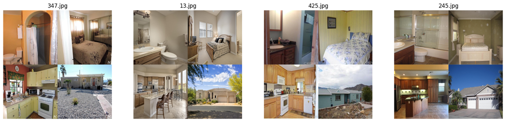

```python
image_files = os.listdir(train_img_dir)
sample = random.sample(image_files, 4)

fig, axes = plt.subplots(1, 4, figsize=(20, 5))

for ax, fname in zip(axes, sample):
    img_path = os.path.join(train_img_dir, fname)
    img = Image.open(img_path)

    ax.imshow(img)
    ax.set_title(fname)
    ax.axis("off")

plt.show()
```

Elke afbeelding in de dataset is een samengevoegde collage van 4 foto's van dezelfde woning,

[output not shown]

Dit geeft het model visuele informatie over de staat en stijl van de woning vanuit meerdere perspectieven.

## 1.2 metadata inladen

Het bestand train.csv bevat de metadata van elke woning, zoals oppervlakte, aantal kamers en de doelvariabele Price.

```python
csv_path = os.path.join(data_dir, "train.csv")
df = pd.read_csv(csv_path)

print("=== Eerste rijen (head) ===")
display(df.head())

print("\n=== Statistische samenvatting (describe) ===")
display(df.describe())
```

```
=== Eerste rijen (head) ===
```

|  | House ID | Bedrooms | Bathrooms | Area | Latitude | Longitude | Price |
| --- | --- | --- | --- | --- | --- | --- | --- |
| 0 | 1 | 4 | 4.0 | 4053 | 33.6968 | -111.8892 | 869500 |
| 1 | 2 | 4 | 3.0 | 3343 | 34.8280 | -119.0349 | 865200 |
| 2 | 3 | 3 | 4.0 | 3923 | 33.7669 | -111.9182 | 889000 |
| 3 | 4 | 5 | 5.0 | 4022 | 33.7752 | -111.7791 | 910000 |
| 4 | 5 | 3 | 4.0 | 4116 | 33.7669 | -111.9182 | 971226 |

```
=== Statistische samenvatting (describe) ===
```

|  | House ID | Bedrooms | Bathrooms | Area | Latitude | Longitude | Price |
| --- | --- | --- | --- | --- | --- | --- | --- |
| count | 500.000000 | 500.000000 | 500.000000 | 500.00000 | 500.000000 | 500.000000 | 5.000000e+02 |
| mean | 250.500000 | 3.350000 | 2.669500 | 2369.64600 | 35.128844 | -116.469049 | 5.980218e+05 |
| std | 144.481833 | 1.172283 | 1.017578 | 1208.18261 | 2.386173 | 6.554434 | 5.240649e+05 |
| min | 1.000000 | 1.000000 | 1.000000 | 701.00000 | 32.631500 | -122.368300 | 2.200000e+04 |
| 25% | 125.750000 | 2.000000 | 2.000000 | 1440.00000 | 33.808200 | -119.802500 | 2.350000e+05 |
| 50% | 250.500000 | 3.000000 | 2.500000 | 2097.50000 | 33.920800 | -117.609600 | 5.300000e+05 |
| 75% | 375.250000 | 4.000000 | 3.000000 | 3104.50000 | 35.640600 | -116.371300 | 7.490000e+05 |
| max | 500.000000 | 10.000000 | 7.000000 | 9583.00000 | 47.791800 | -87.885900 | 5.858000e+06 |

### 1.3 Visualisaties

#### 1.3.1 Scatterplot Oppervlakte vs Prijs

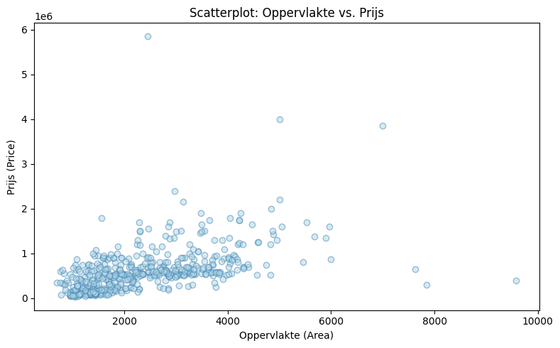

```python
# Scatterplot: Oppervlakte vs. Prijs
fig, ax = plt.subplots(figsize=(8, 5))
ax.scatter(
    df["Area"],
    df["Price"],
    alpha=0.5,
    edgecolors="steelblue",
    facecolors="lightblue",
)
ax.set_xlabel("Oppervlakte (Area)")
ax.set_ylabel("Prijs (Price)")
ax.set_title("Scatterplot: Oppervlakte vs. Prijs")
plt.tight_layout()
plt.show()
```

### Bevindingen

Positieve trend: Over het algemeen geldt hoe groter het huis, hoe hoger de verkoopprijs.

De grote massa: De meeste huizen zijn kleiner dan 4000 vierkante voet en kosten minder dan 1,5 miljoen dollar.

Opvallende uitschieters: Er is bijvoorbeeld een relatief klein huis van bijna 6 miljoen dollar en een gigantisch huis dat relatief goedkoop is.

Conclusie: Oppervlakte is een belangrijke voorspeller, maar om de prijs echt goed te schatten heeft ons model straks absoluut ook de andere gegevens nodig zoals locatie en de foto's.

### 1.6.2 Boxplots: Slaapkamers & Badkamers vs. Prijs

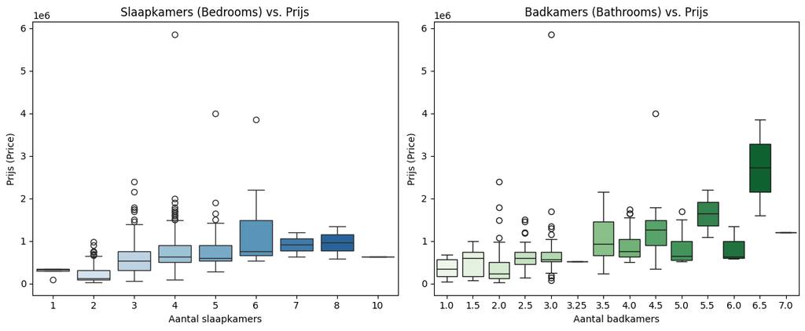

```python
# Boxplots: Slaapkamers & Badkamers vs. Prijs
fig, axes = plt.subplots(1, 2, figsize=(12, 5))

sns.boxplot(data=df, x="Bedrooms", y="Price", ax=axes[0], palette="Blues")
axes[0].set_title("Slaapkamers (Bedrooms) vs. Prijs")
axes[0].set_xlabel("Aantal slaapkamers")
axes[0].set_ylabel("Prijs (Price)")

sns.boxplot(data=df, x="Bathrooms", y="Price", ax=axes[1], palette="Greens")
axes[1].set_title("Badkamers (Bathrooms) vs. Prijs")
axes[1].set_xlabel("Aantal badkamers")
axes[1].set_ylabel("Prijs (Price)")

plt.tight_layout()
plt.show()
```

### Bevindingen

**Relatie Badkamers en Prijs:** Bij de badkamers is de stijgende trend over de hele linie eigenlijk nog iets sterker. Vooral vanaf 3,5 badkamers begint de prijs flink op te lopen. Ook hier is een uitschieter in de categorie met 3 badkamers.

**Conclusie:** Meer kamers betekent meestal een duurder huis, maar het aantal badkamers lijkt een net iets sterkere voorspeller voor huizen in het dure segment dan het aantal slaapkamers.

### 1.6.3 Geografische spreiding van woningprijzen

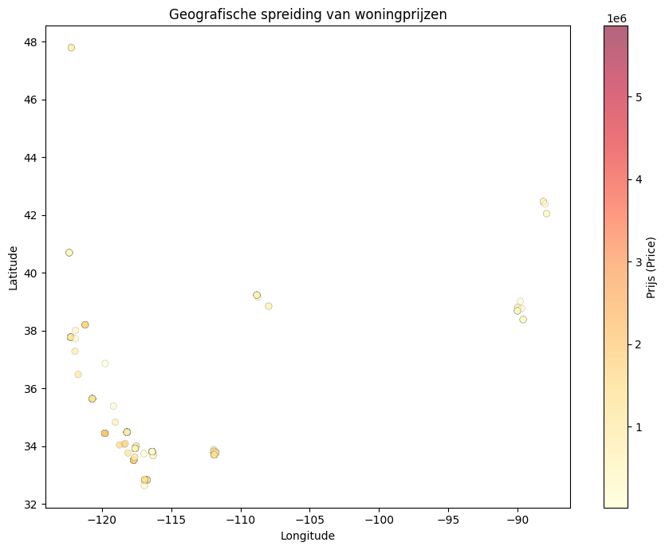

```python
# Geografische scatterplot: Longitude vs. Latitude, gekleurd op Prijs
fig, ax = plt.subplots(figsize=(9, 7))
scatter = ax.scatter(
    df["Longitude"],
    df["Latitude"],
    c=df["Price"],
    cmap="YlOrRd",
    alpha=0.6,
    edgecolors="grey",
    linewidths=0.3,
)
cbar = plt.colorbar(scatter, ax=ax)
cbar.set_label("Prijs (Price)")
ax.set_xlabel("Longitude")
ax.set_ylabel("Latitude")
ax.set_title("Geografische spreiding van woningprijzen")
plt.tight_layout()
plt.show()
```

Geografische clusters: De huizen in onze dataset zijn niet gelijkmatig verspreid, maar liggen in heel duidelijke groepen. We zien een hele grote concentratie aan de linkerkant en een paar kleinere plukjes verder naar het oosten. Er zit een enorm leeg gebied tussenin.

Prijs en locatie: De meeste stippen zijn lichtgeel, wat overeenkomt met de grote massa huizen onder de 1,5 miljoen dollar die we al eerder zagen. maar we zien in de drukke clusters linksonder ook wat donkerdere oranje stippen opduiken.

### 1.6.4 Correlatie-heatmap

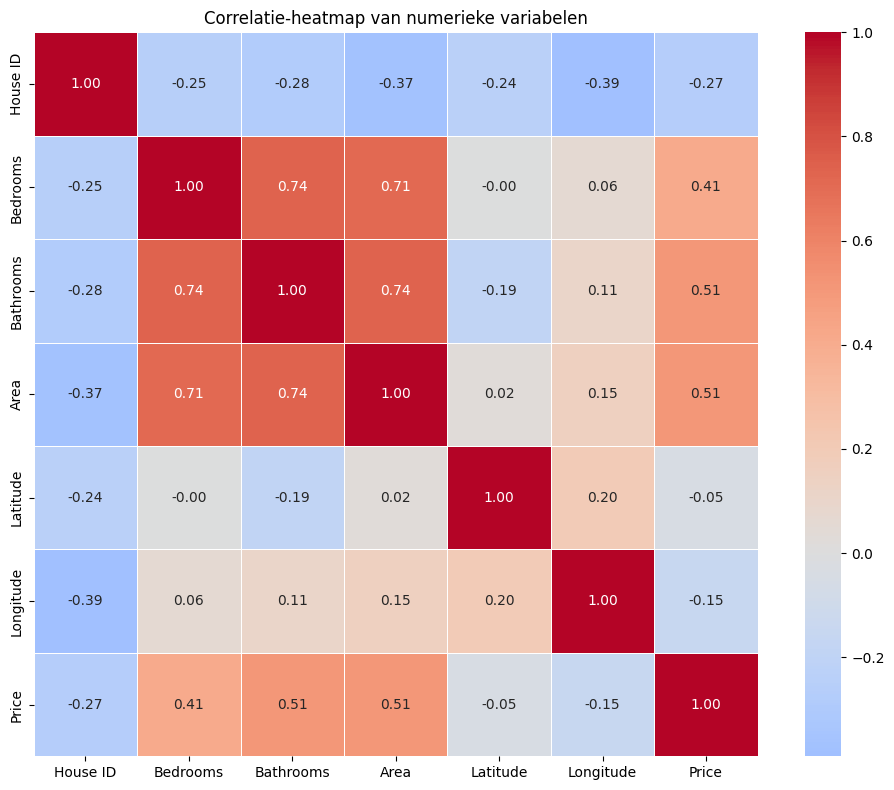

```python
# Correlatie-heatmap van alle numerieke variabelen
numeric_df = df.select_dtypes(include="number")
corr_matrix = numeric_df.corr()

fig, ax = plt.subplots(figsize=(10, 8))
sns.heatmap(
    corr_matrix,
    annot=True,
    fmt=".2f",
    cmap="coolwarm",
    center=0,
    square=True,
    linewidths=0.5,
    ax=ax,
)
ax.set_title("Correlatie-heatmap van numerieke variabelen")
plt.tight_layout()
plt.show()
```

Belangrijkste voorspellers: De oppervlakte en het aantal badkamers hebben de sterkste positieve correlatie met de verkoopprijs beide 0.51. Direct daarna volgt het aantal slaapkamers 0.41. Dit bevestigt dat de grootte en het aantal kamers belangrijke factoren zijn voor een hogere prijs.

Onderlinge samenhang: Er is een sterke samenhang te zien tussen de variabelen Area, Bathrooms en Bedrooms correlaties tussen de 0.71 en 0.74.

Locatie: De lengte en breedtegraad tonen vrijwel geen lineaire correlatie met de prijs -0.15 en -0.05. Dit betekent niet dat locatie onbelangrijk is, maar wel dat de relatie complexer is.

# 2. Opdracht 2: Fully-connected neuraal netwerk

## 2.1 Data Voorbereiding

We gebruiken uitsluitend de tabulaire features uit train.csv:

- Features (X): Bedrooms, Bathrooms, Area, Latitude, Longitude
- Target (y): Price

De data wordt opgesplitst in een trainset (80%) en een validatieset (20%).  
Daarna schalen we de features met StandardScaler.Zonder schaling kunnen grote waarden bijvoorbleed Area de gradientafdaling verstoren en het  
trainen vertragen of instabiel maken.

```python
# Bepaal de features (X) en de target (y)
X = df[['Bedrooms', 'Bathrooms', 'Area', 'Latitude', 'Longitude']]
y = df['Price']

# Splits de data (80% trainen, 20% valideren)
X_train, X_val, y_train, y_val = train_test_split(
    X, y, test_size=0.2, random_state=42
)

# Schaal de features
scaler = StandardScaler()
X_train_scaled = scaler.fit_transform(X_train)
X_val_scaled = scaler.transform(X_val)

print(f"Trainingsdata: {X_train_scaled.shape} (huizen, features)")
print(f"Validatiedata: {X_val_scaled.shape} (huizen, features)")
```

```
Trainingsdata: (400, 5) (huizen, features)
Validatiedata: (100, 5) (huizen, features)
```

## 2.2 Modelarchitectuur bouwen

```python
# Bouw het sequentiele model op
model_tabular = Sequential(name="Tabular_Dense_Network")

model_tabular.add(Dense(256, activation='relu',
                        input_shape=(X_train_scaled.shape[1],),
                        name="Verborgen_Laag_1"))
model_tabular.add(Dense(128, activation='relu', name="Verborgen_Laag_2"))
model_tabular.add(Dense(64, activation='relu', name="Verborgen_Laag_3"))
model_tabular.add(Dense(1, activation='linear', name="Output_Prijs"))
```

## 2.3 Visualisatie van de architectuur

```python
# !pip install graphviz pydot
```

```python
# !brew install graphviz
```

```
Model: "Tabular_Dense_Network"
```

```
┏━━━━━━━━━━━━━━━━━━━━━━━━━━━━━━━━━┳━━━━━━━━━━━━━━━━━━━━━━━━┳━━━━━━━━━━━━━━━┓
┃ Layer (type)                    ┃ Output Shape           ┃       Param # ┃
┡━━━━━━━━━━━━━━━━━━━━━━━━━━━━━━━━━╇━━━━━━━━━━━━━━━━━━━━━━━━╇━━━━━━━━━━━━━━━┩
│ Verborgen_Laag_1 (Dense)        │ (None, 256)            │         1,536 │
├─────────────────────────────────┼────────────────────────┼───────────────┤
│ Verborgen_Laag_2 (Dense)        │ (None, 128)            │        32,896 │
├─────────────────────────────────┼────────────────────────┼───────────────┤
│ Verborgen_Laag_3 (Dense)        │ (None, 64)             │         8,256 │
├─────────────────────────────────┼────────────────────────┼───────────────┤
│ Output_Prijs (Dense)            │ (None, 1)              │            65 │
└─────────────────────────────────┴────────────────────────┴───────────────┘
```

```
 Total params: 42,753 (167.00 KB)
```

```
 Trainable params: 42,753 (167.00 KB)
```

```
 Non-trainable params: 0 (0.00 B)
```

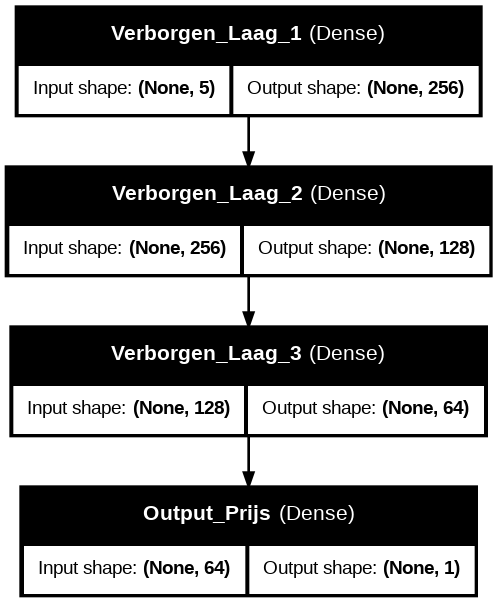

```python
model_tabular.summary()

tf.keras.utils.plot_model(
    model_tabular,
    show_shapes=True,
    show_layer_names=True,
    dpi=96,
)
```

## 2.4 Onderbouwing van keuzes

### Architectuur: trechterstructuur

We hebben gekozen voor een netwerk met drie verborgen lagen die steeds smaller worden. De eerste laag (256 neuronen) geeft het model voldoende capaciteit om complexe patronen te ontdekken in de 5 inputfeatures, zoals de wisselwerking tussen locatie en oppervlakte. De tweede laag (128) en derde laag (64) dwingen het model om de geleerde informatie steeds compacter samen te vatten. Deze trechterstructuur helpt overfitting te voorkomen: het model kan niet simpelweg alle trainingsdata uit het hoofd leren, maar moet de onderliggende relaties abstraheren.

### Activeringsfuncties

In de verborgen lagen gebruiken we ReLU.Het zet negatieve waarden op nul en laat positieve waarden onveranderd door. Dit is de standaardkeuze voor verborgen lagen omdat het twee voordelen heeft: het is rekenkundig snel, en het voorkomt het *vanishing gradient* probleem dat bij oudere functies zoals sigmoid optreedt.

De outputlaag gebruikt een lineaire activatie. Dit is noodzakelijk voor een regressieprobleem. we voorspellen een continu getal dat niet begrensd mag worden.

## 2.5 Keuze voor lossfunctie en optimizer

### Lossfunctie: MAPE

We gebruiken MAPE als lossfunctie. MAPE berekent de gemiddelde procentuele afwijking tussen de voorspelde en werkelijke prijs:

$$\text{MAPE} = \frac{100}{n} \sum_{i=1}^{n} \left| \frac{y_i - \hat{y}_i}{y_i} \right|$$

Dit is de meest geschikte keuze voor dit probleem omdat de huizenprijzen in de dataset enorm variëren. Bij een absolute lossfunctie zoals MAE zou een fout van 50.000 voor elk huis even zwaar wegen. Maar een fout van 50.000 bij een huis van 100.000 (50% fout) is veel ernstiger dan bij een huis van 3 miljoen (1,7% fout). MAPE weegt fouten relatief, waardoor het model eerlijk leert over alle prijsklassen.

### Optimizer: Adam

Adam combineert twee technieken:

1. Momentum : het model onthoudt de richting van eerdere gradiëntstappen en beweegt daar naartoe. Dit voorkomt dat het model heen en weer springt.
2. Adaptieve learning rate : elke parameter krijgt zijn eigen leersnelheid. Parameters die al vaak zijn bijgesteld nemen kleinere stappen, terwijl weinig bijgestelde parameters grotere stappen mogen nemen.

We starten met een learning rate van 0.001, wat de standaard is voor Adam. In combinatie met ReduceLROnPlateau wordt de learning rate automatisch gehalveerd als het model vastloopt, zodat het fijner kan afstellen in latere epochs.

```
Start training Dense netwerk...
```

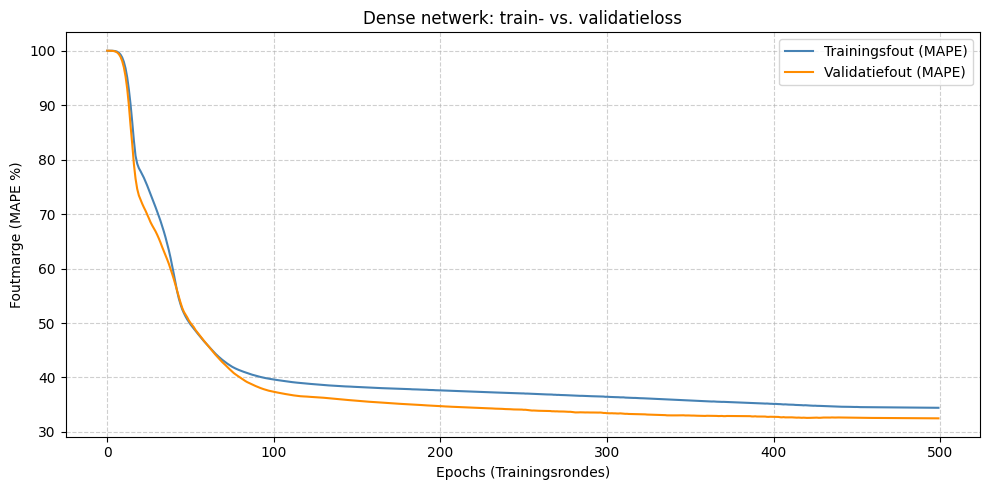

```
Gestopt na 500 epochs.
Beste validatie MAPE: 32.50%
In decimaal formaat: 0.3250
```

```python
# Zet een vaste seed voor reproduceerbaarheid
tf.random.set_seed(42)
np.random.seed(42)

# Compileer het model
model_tabular.compile(
    optimizer=Adam(learning_rate=1e-3),
    loss='mean_absolute_percentage_error'
)

# Callbacks
early_stop = EarlyStopping(
    monitor='val_loss',
    patience=50,
    restore_best_weights=True
)

reduce_lr = ReduceLROnPlateau(
    monitor='val_loss',
    factor=0.5,
    patience=15,
    min_lr=1e-6
)

# Train het model
print("Start training Dense netwerk...")
history_tabular = model_tabular.fit(
    X_train_scaled, y_train,
    validation_data=(X_val_scaled, y_val),
    epochs=500,
    batch_size=32,
    callbacks=[early_stop, reduce_lr],
    verbose=0
)

# Plot en score
plot_training_history(history_tabular, "Dense netwerk: train- vs. validatieloss")

best_mape_tabular = min(history_tabular.history['val_loss'])
print(f"Gestopt na {len(history_tabular.history['loss'])} epochs.")
print(f"Beste validatie MAPE: {best_mape_tabular:.2f}%")
print(f"In decimaal formaat: {best_mape_tabular / 100:.4f}")
```

### 2.6 Evaluatie

Het Dense netwerk behaalt een beste validatie MAPE van circa 32%, wat neerkomt op een gemiddelde voorspelfout van 32% ten opzichte van de werkelijke prijs.

Het model stopt na 500 epochs, wat aangeeft dat het nog langzaam aan het verbeteren was. De ReduceLROnPlateau callback heeft de learning rate meerdere keren verlaagd, waardoor het model in de latere epochs beter kon worden.

# 3. Opdracht 3: Convolutioneel neuraal netwerk

In deze deelopdracht werken we alleen met de afbeeldingen en de prijslabels.  
We bouwen een CNN dat op basis van de huizenfoto's de verkoopprijs probeert te voorspellen.

## 3.1 Datapijplijn: Afbeeldingen inladen en voorbereiden

```python
# Laad afbeeldingen met de gedeelde functie
X_images, y_prices = load_images_and_labels(train_img_dir, csv_path)

# Splits in train en validatie
X_train_img, X_val_img, y_train_img, y_val_img = train_test_split(
    X_images, y_prices, test_size=0.2, random_state=42
)

print(f"Afbeeldingen: {X_images.shape}")
print(f"Trainset:     {X_train_img.shape[0]} afbeeldingen")
print(f"Validatieset: {X_val_img.shape[0]} afbeeldingen")
print(f"Pixelwaarden: [{X_images.min():.2f}, {X_images.max():.2f}]")
```

```
Afbeeldingen: (500, 240, 240, 3)
Trainset:     400 afbeeldingen
Validatieset: 100 afbeeldingen
Pixelwaarden: [0.00, 1.00]
```

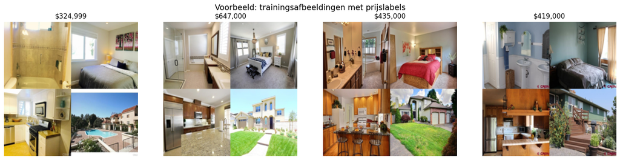

```python
# Toon 4 willekeurige trainingsafbeeldingen met hun prijs
fig, axes = plt.subplots(1, 4, figsize=(16, 4))
sample_indices = random.sample(range(len(X_train_img)), 4)

for ax, idx in zip(axes, sample_indices):
    ax.imshow(X_train_img[idx])
    ax.set_title(f"${y_train_img[idx]:,.0f}")
    ax.axis("off")

plt.suptitle("Voorbeeld: trainingsafbeeldingen met prijslabels", fontsize=14)
plt.tight_layout()
plt.show()
```

## 3.2 Data Augmentation

Omdat we slechts 500 afbeeldingen hebben, is het risico op overfitting groot. Data augmentation helpt door tijdens het trainen willekeurige transformaties op de afbeeldingen toe te passen. Het model doorloopt nog steeds alle afbeeldingen per epoch, maar ziet elke afbeelding telkens in een iets andere variant. Hierdoor lijkt de dataset effectief groter en leert het model de onderliggende patronen in plaats van specifieke pixels uit het hoofd te leren.

### Geschikte vormen

- Horizontaal spiegelen — Een huis ziet er gespiegeld nog steeds realistisch uit.
- Kleine rotatie — Foto's zijn niet altijd perfect recht genomen.
- Lichte zoom — Simuleert dat foto's van iets dichterbij of verder weg zijn genomen.
- Kleine verschuiving — Alsof de camera niet precies gecentreerd was.

### Ongeschikte vormen

- Verticaal spiegelen — Een huis op kop is onrealistisch.
- Grote rotaties — Huizen worden niet zijwaarts gefotografeerd.
- Extreme kleurveranderingen — De kleur en staat van een keuken of badkamer is juist een belangrijke prijsindicator.

```python
# Data augmentation alleen voor trainingsdata
train_datagen = ImageDataGenerator(
    horizontal_flip=True,
    rotation_range=10,
    zoom_range=0.1,
    width_shift_range=0.05,
    height_shift_range=0.05,
    fill_mode='nearest'
)

# Validatiedata wordt NIET geaugmenteerd
val_datagen = ImageDataGenerator()

# Generators aanmaken
train_generator = train_datagen.flow(
    X_train_img, y_train_img, batch_size=BATCH_SIZE, shuffle=True
)
val_generator = val_datagen.flow(
    X_val_img, y_val_img, batch_size=BATCH_SIZE, shuffle=False
)

print(f"Train generator: {len(train_generator)} batches per epoch")
print(f"Validatie generator: {len(val_generator)} batches per epoch")
```

```
Train generator: 13 batches per epoch
Validatie generator: 4 batches per epoch
```

## 3.3 CNN-architectuur bouwen

We bouwen een CNN voor regressie. het model krijgt een afbeelding als invoer en geeft een getal terug de voorspelde huizenprijs.

### Architectuurkeuzes

- **4 convolutieblokken** — Elk blok bestaat uit Conv2D en BatchNormalization en MaxPooling2D. Het aantal filters verdubbelt per blok, zodat het model van eenvoudige kenmerken naar complexere patronen leert.
- **GlobalAveragePooling2D** — Middelt elk van de 256 feature-kanalen uit tot 1 getal 256 waarden totaal. Dit is veel compacter dan Flatten.
- **Dense** — Na de convolutielagen vertaalt de trechter de visuele kenmerken naar een prijsvoorspelling. Dropout voorkomt dat deze lagen te afhankelijk worden van specifieke neuronen.
- **Lineaire output** — Een neuron zonder activatie, want we voorspellen een continu getal.

```python
def build_cnn_model(input_shape=(IMG_SIZE, IMG_SIZE, 3), l2_strength=1e-4):

    reg = l2(l2_strength)
    model = Sequential(name="CNN_Neural_Estate")

    # Convolutieblok 1: lage-niveau kenmerken
    model.add(Conv2D(32, (3, 3), activation='relu', padding='same',
                     kernel_regularizer=reg, input_shape=input_shape, name="Conv1"))
    model.add(BatchNormalization(name="BN1"))
    model.add(MaxPooling2D((2, 2), name="Pool1"))

    # Convolutieblok 2
    model.add(Conv2D(64, (3, 3), activation='relu', padding='same',
                     kernel_regularizer=reg, name="Conv2"))
    model.add(BatchNormalization(name="BN2"))
    model.add(MaxPooling2D((2, 2), name="Pool2"))

    # Convolutieblok 3
    model.add(Conv2D(128, (3, 3), activation='relu', padding='same',
                     kernel_regularizer=reg, name="Conv3"))
    model.add(BatchNormalization(name="BN3"))
    model.add(MaxPooling2D((2, 2), name="Pool3"))

    # Convolutieblok 4
    model.add(Conv2D(256, (3, 3), activation='relu', padding='same',
                     kernel_regularizer=reg, name="Conv4"))
    model.add(BatchNormalization(name="BN4"))
    model.add(MaxPooling2D((2, 2), name="Pool4"))

    # GlobalAveragePooling
    model.add(GlobalAveragePooling2D(name="GAP"))

    # Dense trechter
    model.add(Dense(512, activation='relu', kernel_regularizer=reg, name="Dense1"))
    model.add(Dropout(0.5, name="Dropout1"))
    model.add(Dense(128, activation='relu', name="Dense2"))
    model.add(Dropout(0.3, name="Dropout2"))

    # Output: 1 neuron, lineaire activatie voor regressie
    model.add(Dense(1, activation='linear', name="Output_Prijs"))

    return model


# Bouw het model
model_cnn = build_cnn_model()
print("CNN-model aangemaakt.")
```

```
CNN-model aangemaakt.
```

## 3.4 Regularisatie: onderbouwing

Met slechts 400 trainingsafbeeldingen is overfitting de grootste bedreiging. We combineren vier technieken:

### L2-regularisatie op de convolutielagen

L2 voegt een straf toe aan de lossfunctie die evenredig is met het kwadraat van de gewichten. Grote gewichten worden actief ontmoedigd, wat voorkomt dat de convolutiefilters te specifieke patronen leren die alleen in de trainingsdata voorkomen. We gebruiken een sterkte van λ = 1e-4.

### Dropout

Dropout schakelt tijdens elke trainingsronde een willekeurig percentage neuronen uit. Het netwerk kan daardoor niet leunen op een vaste set verbindingen en leert robuustere representaties. We gebruiken Dropout(0.5) na de eerste Dense laag en Dropout(0.3) na de tweede.

### BatchNormalization

BatchNormalization normaliseert de activaties per mini-batch naar gemiddelde 0 en variantie 1. Dit stabiliseert de training en heeft een licht regulariserend effect door de ruis in de batch-statistieken.

## 3.5 Architectuur visualiseren

```python
model_cnn.summary()
```

[output not shown]

[figure not shown]

```python
# model_cnn.summary()

tf.keras.utils.plot_model(
    model_cnn,
    show_shapes=True,
    show_layer_names=True,
    dpi=96,
)
```

## 3.6 Model compileren

We gebruiken MAPE als lossfunctie en Adam als optimizer. De learning rate is verlaagd naar 3×10⁻⁴ ten opzichte van opdracht 2. Daarnaast voegen we ReduceLROnPlateau toe als de validatieloss 10 epochs niet daalt, wordt de learning rate gehalveerd.

```
Start training CNN...
```

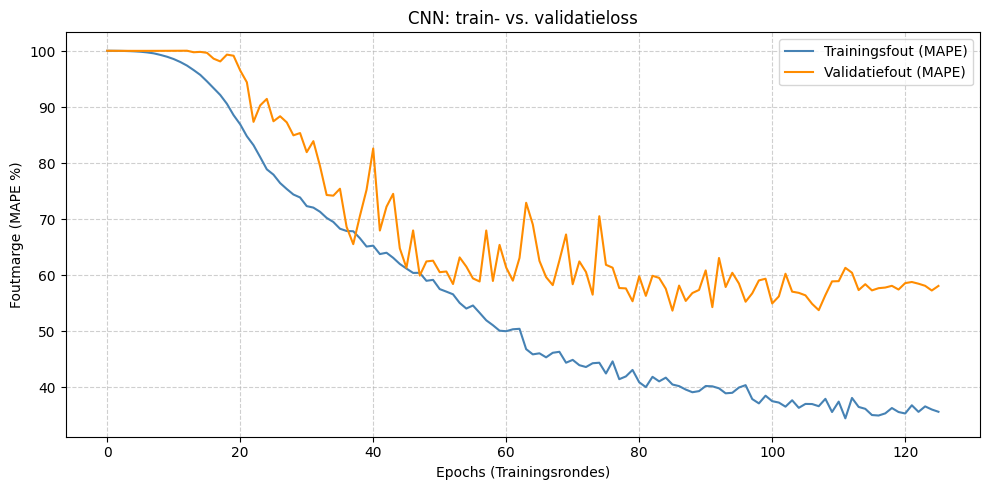

```
Training gestopt na 126 epochs.
Beste validatie MAPE (CNN): 53.68%
```

```python
# Compileer het model
model_cnn.compile(
    optimizer=Adam(learning_rate=3e-4),
    loss='mean_absolute_percentage_error'
)

# Callbacks
early_stop_cnn = EarlyStopping(
    monitor='val_loss', patience=40,
    restore_best_weights=True, verbose=0
)
reduce_lr_cnn = ReduceLROnPlateau(
    monitor='val_loss', factor=0.5,
    patience=10, min_lr=1e-6, verbose=0
)

# Train het model met augmentatie generators
print("Start training CNN...")
history_cnn = model_cnn.fit(
    train_generator,
    validation_data=val_generator,
    epochs=200,
    callbacks=[early_stop_cnn, reduce_lr_cnn],
    verbose=0
)

# Plot en score
plot_training_history(history_cnn, "CNN: train- vs. validatieloss")

best_mape_cnn = min(history_cnn.history['val_loss'])
print(f"Training gestopt na {len(history_cnn.history['loss'])} epochs.")
print(f"Beste validatie MAPE (CNN): {best_mape_cnn:.2f}%")
```

# 4. Transfer learning

In deze deelopdracht gebruiken we een voorgetraind model (MobileNetV2) en fine-tunen dit op de huizenfoto's. We werken weer alleen met afbeeldingen en prijslabels, zonder tabeldata.

## 4.1 Keuze van het voorgetrainde model

### Wat is transfer learning?

Transfer learning houdt in dat we een model gebruiken dat al getraind is op een grote dataset in dit geval ImageNet, 14 miljoen afbeeldingen in 1000 categorieen. Dit model heeft al geleerd hoe het visuele kenmerken moet herkennen: randen, texturen, vormen en objecten. Wij nemen die kennis over en passen het model aan voor onze specifieke taak huizenprijzen voorspellen.

### Voordelen van voorgetrainde modellen

1. Betere features met minder data — Het model heeft al miljoenen afbeeldingen gezien en hoeft niet vanaf nul te leren wat een rand of textuur is.
2. Snellere convergentie — Omdat de basiskennis al aanwezig is, hoeft het model alleen de relatie visueel kenmerk prijs te leren in plaats van alles tegelijk.
3. Robuustere representaties — Features geleerd op miljoenen diverse afbeeldingen generaliseren beter dan features geleerd op 400 huizenfoto's.

### Modelkeuze: MobileNetV2

We kiezen MobileNetV2, voorgetraind op ImageNet. MobileNetV2 is ontworpen voor efficientie. Het gebruikt depthwise separable convolutions die minder parameters nodig hebben dan standaard convoluties. Het is lichter dan ResNet50, wat het geschikter maakt voor onze kleine dataset waar overfitting een risico is.

## 4.2 Model laden en lagen bevriezen

We laden MobileNetV2 zonder de classificatiekop, omdat die was getraind om ImageNet-categorieen te herkennen. In plaats daarvan voegen we onze eigen lagen toe voor prijsregressie.

Alle lagen van het basismodel worden bevroren. Dit betekent dat de gewichten niet worden bijgewerkt tijdens fase 1 van het trainen. Het model gebruikt de voorgetrainde kennis wel voor de forward pass, maar past deze niet aan. Alleen de nieuwe lagen die we toevoegen worden getraind.

MobileNetV2 verwacht pixels in het bereik [-1, 1]. Onze afbeeldingen zijn genormaliseerd naar [0, 1], dus we voegen een Lambda-laag toe die de schaling uitvoert.

```python
# Transfer learning vereist 224x224 afbeeldingen
IMG_SIZE_TL = 224

X_images_tl, y_prices_tl = load_images_and_labels(
    train_img_dir, csv_path, img_size=IMG_SIZE_TL
)

X_train_img_tl, X_val_img_tl, y_train_tl, y_val_tl = train_test_split(
    X_images_tl, y_prices_tl, test_size=0.2, random_state=42
)

# Augmentatie generators voor 224x224 afbeeldingen
train_gen_tl = train_datagen.flow(
    X_train_img_tl, y_train_tl, batch_size=16, shuffle=True
)
val_gen_tl = val_datagen.flow(
    X_val_img_tl, y_val_tl, batch_size=16, shuffle=False
)

print(f"Train: {X_train_img_tl.shape}")
print(f"Val:   {X_val_img_tl.shape}")
```

```
Train: (400, 224, 224, 3)
Val:   (100, 224, 224, 3)
```

```python
from tensorflow.keras.applications import MobileNetV2  # pyright: ignore[reportMissingImports]

# Laad MobileNetV2 zonder classificatiekop
base_model = MobileNetV2(
    weights='imagenet',
    include_top=False,
    input_shape=(IMG_SIZE_TL, IMG_SIZE_TL, 3)
)
base_model.trainable = False

# Bouw het volledige model
model_tl = tf.keras.Sequential([
    tf.keras.layers.Input(shape=(IMG_SIZE_TL, IMG_SIZE_TL, 3)),
    tf.keras.layers.Lambda(lambda x: (x - 0.5) * 2.0),  # Schaal naar [-1, 1]
    base_model,
    GlobalAveragePooling2D(),
    Dense(256, activation='relu'),
    Dropout(0.5),
    Dense(64, activation='relu'),
    Dropout(0.3),
    Dense(1, activation='linear')
])

# Toon het aantal parameters
total = model_tl.count_params()
trainable = sum(tf.keras.backend.count_params(w) for w in model_tl.trainable_weights)
frozen = total - trainable
print(f"Totaal parameters:      {total:,}")
print(f"Trainbaar:              {trainable:,}")
print(f"Bevroren:               {frozen:,}")
```

```
Downloading data from https://storage.googleapis.com/tensorflow/keras-applications/mobilenet_v2/mobilenet_v2_weights_tf_dim_ordering_tf_kernels_1.0_224_no_top.h5
9406464/9406464 ━━━━━━━━━━━━━━━━━━━━ 0s 0us/step
Totaal parameters:      2,602,433
Trainbaar:              344,449
Bevroren:               2,257,984
```

## 4.3 Nieuwe lagen en fine-tuning

### Toegevoegde lagen

Bovenop het bevroren MobileNetV2 voegen we toe:

- **GlobalAveragePooling2D** — Reduceert de feature maps naar 1280 waarden (het aantal outputkanalen van MobileNetV2).
- **Dense(256, relu) + Dropout(0.5)** — Eerste vertaallaag van visuele features naar prijsinformatie, met sterke dropout om overfitting te voorkomen.
- **Dense(64, relu) + Dropout(0.3)** — Tweede trechterlaag voor verdere abstractie.
- **Dense(1, linear)** — Outputlaag voor de prijsregressie.

### Trainingsstrategie in twee fasen

Fase 1 — Bevroren We trainen alleen de nieuwe lagen met een learning rate van 1e-3. De voorgetrainde gewichten blijven ongewijzigd. Dit geeft de nieuwe lagen de kans om te leren hoe de bestaande features samenhangen met huizenprijzen.

Fase 2 — Fine-tuning: We ontdooien de laatste 30 lagen van MobileNetV2 en trainen opnieuw met een veel lagere learning rate (1e-5). Dit laat de bovenste convolutielagen zich aanpassen aan huizenfoto's specifiek, zonder de universele kenmerken in de onderste lagen te verstoren.

## 4.4 Fase 1: Trainen met bevroren basis

[output not shown]

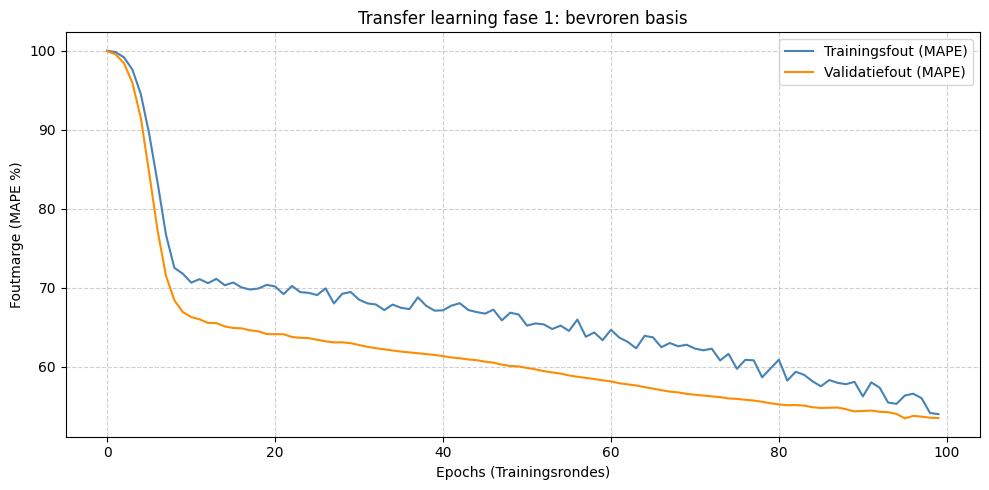

```
Beste val MAPE fase 1: 53.50%
```

```python
# Compileer voor fase 1
model_tl.compile(
    optimizer=Adam(learning_rate=1e-3),
    loss='mean_absolute_percentage_error'
)

early_stop_tl1 = EarlyStopping(
    monitor='val_loss', patience=30, restore_best_weights=True
)

# Fase 1 training
history_tl1 = model_tl.fit(
    train_gen_tl,
    validation_data=val_gen_tl,
    epochs=100,
    callbacks=[early_stop_tl1],
    verbose=0
)

plot_training_history(history_tl1, "Transfer learning fase 1: bevroren basis")
best_mape_tl1 = min(history_tl1.history['val_loss'])
print(f"Beste val MAPE fase 1: {best_mape_tl1:.2f}%")
```

## 4.5 Fase 2: Fine-tuning

```
Start fase 2: fine-tuning...
```

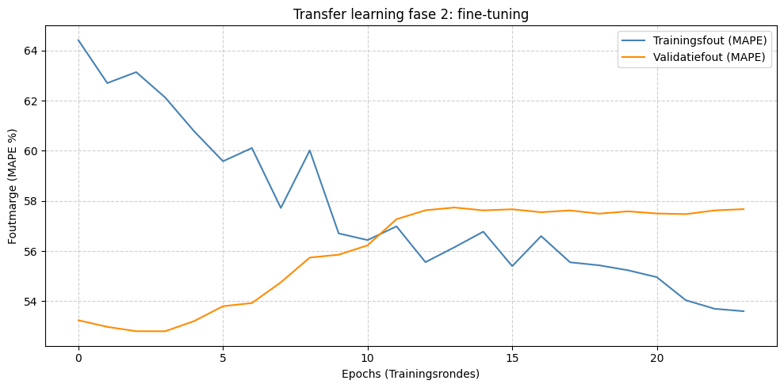

```
Beste val MAPE fase 2: 52.80%

--- Vergelijking ---
Fase 1 (bevroren): 53.50%
Fase 2 (fine-tuned): 52.80%
Verbetering: 0.70%
```

```python
# Ontdooi de laatste 30 lagen van het basismodel
base_model.trainable = True
for layer in base_model.layers[:-30]:
    layer.trainable = False

# Compileer opnieuw met lagere learning rate
model_tl.compile(
    optimizer=Adam(learning_rate=1e-5),
    loss='mean_absolute_percentage_error'
)

reduce_lr_tl = ReduceLROnPlateau(
    monitor='val_loss', factor=0.5, patience=8, min_lr=1e-7
)
early_stop_tl2 = EarlyStopping(
    monitor='val_loss', patience=20, restore_best_weights=True
)

# Fase 2 training
print("Start fase 2: fine-tuning...")
history_tl2 = model_tl.fit(
    train_gen_tl,
    validation_data=val_gen_tl,
    epochs=100,
    callbacks=[reduce_lr_tl, early_stop_tl2],
    verbose=0
)

plot_training_history(history_tl2, "Transfer learning fase 2: fine-tuning")
best_mape_tl2 = min(history_tl2.history['val_loss'])
print(f"Beste val MAPE fase 2: {best_mape_tl2:.2f}%")

# Vergelijking
print(f"\n--- Vergelijking ---")
print(f"Fase 1 (bevroren): {best_mape_tl1:.2f}%")
print(f"Fase 2 (fine-tuned): {best_mape_tl2:.2f}%")
print(f"Verbetering: {best_mape_tl1 - best_mape_tl2:.2f}%")
```

# 5.Multimodaal model

In deze deelopdracht combineren we beide databronnen de afbeeldingen en de tabeldata. We bouwen een multimodaal model met twee parallelle takken die samenkomen tot een prijsvoorspelling.

## 5.1 Data voorbereiding: afbeeldingen en tabeldata

```python
# Bouw 15 features voor elk huis met de gedeelde functie
X_tabular_fe = np.array(
    [bouw_features_v2(row) for _, row in df.iterrows()],
    dtype=np.float32
)

# Splits alles tegelijk zodat de koppeling behouden blijft
X_train_img_mm, X_val_img_mm, X_train_tab_mm, X_val_tab_mm, y_train_mm, y_val_mm = train_test_split(
    X_images, X_tabular_fe, y_prices,
    test_size=0.2, random_state=42
)

# Schaal de tabeldata
scaler_mm = StandardScaler()
X_train_tab_mm_scaled = scaler_mm.fit_transform(X_train_tab_mm)
X_val_tab_mm_scaled = scaler_mm.transform(X_val_tab_mm)

print(f"Afbeeldingen train: {X_train_img_mm.shape}")
print(f"Tabeldata train:    {X_train_tab_mm_scaled.shape}")
print(f"Prijzen train:      {y_train_mm.shape}")
```

```
Afbeeldingen train: (400, 240, 240, 3)
Tabeldata train:    (400, 15)
Prijzen train:      (400,)
```

## 5.2 Multimodaal model bouwen

### Architectuurkeuzes

Het model bestaat uit drie onderdelen:

CNN: 3 convolutieblokken elk met Conv2D, BatchNormalization, en MaxPooling2D, gevolgd door GlobalAveragePooling2D en een Dense laag van 128 neuronen. Deze tak extraheert visuele kenmerken zoals de staat van de keuken, badkamer en het vooraanzicht.

Dense: 2 Dense lagen die de 15 feature-engineered kenmerken verwerken. oppervlakte, locatie, kamers, en de afgeleide features zoals afstand tot het Phoenix-cluster en oppervlakte per slaapkamer.

Concatenatie: De outputs van beide takken worden aan elkaar geplakt. We kiezen concatenatie boven optellen of vermenigvuldigen omdat de twee bronnen fundamenteel andere informatie bevatten. Concatenatie laat de Dense lagen na de fusie zelf leren hoe ze de twee bronnen het beste combineren.

Fusie lagen Na de concatenatie volgen twee Dense lagen met Dropout die leren hoe visuele en numerieke informatie samen de prijs bepalen.

Output 1 neuron met ReLU activatie. De ReLU dient als output constraint: het model kan geen negatieve prijzen voorspellen, wat de MAPE stabiliseert.

```python
def build_multimodal_model(img_shape=(IMG_SIZE, IMG_SIZE, 3), n_tab_features=15):
    # CNN voor afbeeldingen
    img_input = Input(shape=img_shape, name="Afbeelding_Input")

    x = Conv2D(32, (3, 3), activation='relu', padding='same', name="MM_Conv1")(img_input)
    x = BatchNormalization(name="MM_BN1")(x)
    x = MaxPooling2D((2, 2), name="MM_Pool1")(x)

    x = Conv2D(64, (3, 3), activation='relu', padding='same', name="MM_Conv2")(x)
    x = BatchNormalization(name="MM_BN2")(x)
    x = MaxPooling2D((2, 2), name="MM_Pool2")(x)

    x = Conv2D(128, (3, 3), activation='relu', padding='same', name="MM_Conv3")(x)
    x = BatchNormalization(name="MM_BN3")(x)
    x = MaxPooling2D((2, 2), name="MM_Pool3")(x)

    x = GlobalAveragePooling2D(name="MM_GAP")(x)
    x = Dense(128, activation='relu', name="MM_CNN_Dense")(x)
    x = Dropout(0.3, name="MM_CNN_Dropout")(x)

    # Dense netwerk voor tabeldata
    tab_input = Input(shape=(n_tab_features,), name="Tabel_Input")

    y = Dense(64, activation='relu', name="MM_Tab_Dense1")(tab_input)
    y = Dense(32, activation='relu', name="MM_Tab_Dense2")(y)
    y = Dropout(0.2, name="MM_Tab_Dropout")(y)

    # FUSIE
    combined = Concatenate(name="Fusie")([x, y])

    z = Dense(128, activation='relu', name="Fusie_Dense1")(combined)
    z = Dropout(0.3, name="Fusie_Dropout1")(z)
    z = Dense(64, activation='relu', name="Fusie_Dense2")(z)
    z = Dropout(0.2, name="Fusie_Dropout2")(z)

    # Output: relu voorkomt negatieve prijzen
    output = Dense(1, activation='relu', name="Output_Prijs")(z)

    model = Model(
        inputs=[img_input, tab_input],
        outputs=output,
        name="Multimodaal_Model"
    )
    return model


model_mm = build_multimodal_model()
```

## 5.3 Architectuur visualiseren

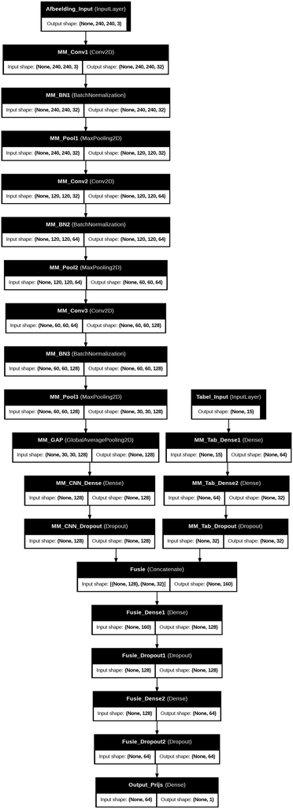

```python
tf.keras.utils.plot_model(
    model_mm,
    show_shapes=True,
    show_layer_names=True,
    dpi=96,
)
```

## 5.4 Model compileren en trainen

We gebruiken dezelfde lossfunctie (MAPE) en optimizer (Adam) als bij de vorige opdrachten. Het model ontvangt twee inputs als een lijst afbeeldingen en tabeldata. Keras weet welke array bij welke input hoort op basis van de volgorde waarin de Input-lagen zijn gedefinieerd.

```
Epoch 25: ReduceLROnPlateau reducing learning rate to 0.0005000000237487257.

Epoch 51: ReduceLROnPlateau reducing learning rate to 0.0002500000118743628.

Epoch 61: ReduceLROnPlateau reducing learning rate to 0.0001250000059371814.

Epoch 71: ReduceLROnPlateau reducing learning rate to 6.25000029685907e-05.
Epoch 71: early stopping
Restoring model weights from the end of the best epoch: 41.
```

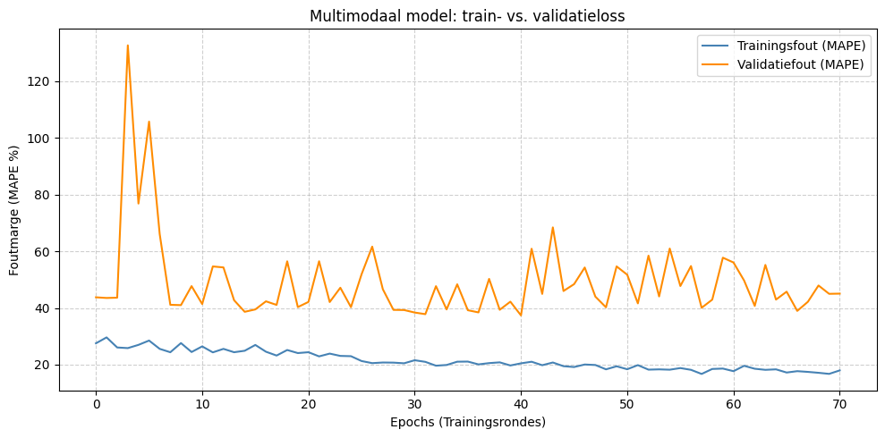

```
Training gestopt na 71 epochs.
Beste validatie MAPE (multimodaal): 37.38%
```

```python
# Compileer het model
model_mm.compile(
    optimizer=Adam(learning_rate=1e-3),
    loss='mean_absolute_percentage_error'
)

# Callbacks
early_stop_mm = EarlyStopping(
    monitor='val_loss', patience=30,
    restore_best_weights=True, verbose=1
)
reduce_lr_mm = ReduceLROnPlateau(
    monitor='val_loss', factor=0.5,
    patience=10, min_lr=1e-6, verbose=1
)

# Train met twee inputs
history_mm = model_mm.fit(
    [X_train_img_mm, X_train_tab_mm_scaled],
    y_train_mm,
    validation_data=([X_val_img_mm, X_val_tab_mm_scaled], y_val_mm),
    epochs=200,
    batch_size=BATCH_SIZE,
    callbacks=[early_stop_mm, reduce_lr_mm],
    verbose=0
)

# Plot en score
plot_training_history(history_mm, "Multimodaal model: train- vs. validatieloss")

best_mape_mm = min(history_mm.history['val_loss'])
print(f"Training gestopt na {len(history_mm.history['loss'])} epochs.")
print(f"Beste validatie MAPE (multimodaal): {best_mape_mm:.2f}%")
```

### 5.5 Submission: multimodaal model

```python
df_test = pd.read_csv(test_csv_path)

test_images = []
test_ids = []

for _, row in df_test.iterrows():
    img_path = os.path.join(test_img_dir, f"{int(row['House ID'])}.jpg")
    if os.path.exists(img_path):
        img = Image.open(img_path).convert("RGB")
        img = img.resize((IMG_SIZE, IMG_SIZE))
        test_images.append(np.array(img) / 255.0)
    else:
        # Ontbrekende afbeelding: zwart beeld als fallback
        test_images.append(np.zeros((IMG_SIZE, IMG_SIZE, 3)))
    test_ids.append(int(row['House ID']))

X_test_img = np.array(test_images, dtype=np.float32)
print(f"Testafbeeldingen geladen: {X_test_img.shape}")

# 3. Feature engineering voor tabeldata (dezelfde 15 features als bij training)
X_test_tab = np.array(
    [bouw_features_v2(row) for _, row in df_test.iterrows()],
    dtype=np.float32
)

# 4. Schaal met de scaler die op de traindata is gefitted
X_test_tab_scaled = scaler_mm.transform(X_test_tab)

# 5. Voorspel prijzen met model_mm
y_pred_mm = model_mm.predict(
    [X_test_img, X_test_tab_scaled],
    verbose=0
).flatten()

# 6. Bouw en sla de submission op
submission_mm = pd.DataFrame({
    'House ID': test_ids,
    'Price':    y_pred_mm
})

submission_path = os.path.join(data_dir, 'submission_mm.csv')
submission_mm.to_csv(submission_path, index=False)

print(f"Submission opgeslagen op: {submission_path}")
print(f"Aantal voorspellingen:    {len(submission_mm)}")
print(submission_mm.head())
```

```
Testafbeeldingen geladen: (35, 240, 240, 3)
Submission opgeslagen op: /content/drive/MyDrive/Neural_Estate/submission_mm.csv
Aantal voorspellingen:    35
   House ID          Price
0       501  257772.187500
1       502  406318.750000
2       503  316229.812500
3       504  423607.625000
4       505  243936.828125
```

# Opdracht 6: Bevindingen

### 6.1 Overzicht van de resultaten

We hebben vier modellen getraind en ingediend op Kaggle. Elke inzending bouwde voort op de vorige:

[output not shown]

## 6.2 Beste model en parameters

Het **multimodale model** presteert het beste (Kaggle MAPE: **38.37%**).

**Architectuur:**

- CNN-tak: 3 Conv2D-blokken (32 → 64 → 128 filters) + GlobalAveragePooling2D + Dense(128)
- Tabel-tak: Dense(64) → Dense(32), op 15 feature-engineered kenmerken
- Fusie: Concatenatie → Dense(128) → Dense(64) → Output (ReLU)

**Trainingsparameters:**

- Lossfunctie: MAPE
- Optimizer: Adam, learning rate 1e-3
- Callbacks: EarlyStopping (patience=30), ReduceLROnPlateau (factor=0.5, patience=10)
- Batch size: 32, max epochs: 200

# 7. Conclusie en aanbevelingen

### 7.1 Conclusie

Het doel van dit project was om een neuraal netwerk te bouwen dat de verkoopprijs van woningen zo nauwkeurig mogelijk voorspelt op basis van afbeeldingen en tabeldata.

We hebben vier modellen getraind en vergeleken:

| Model | Kaggle MAPE |
| --- | --- |
| Dense netwerk (tabeldata) | 41.94% |
| CNN from scratch (afbeeldingen) | 55.49% |
| Transfer learning MobileNetV2 | 52.42% |
| **Multimodaal (afbeeldingen en tabeldata)** | **38.37%** |

Het **multimodale model** presteert het beste met een Kaggle MAPE van **38.37%**. Dit laat zien dat het combineren van twee databronnen — afbeeldingen én tabeldata — beter werkt dan elk van de bronnen apart.

De tabeldata (locatie, oppervlakte, aantal kamers) vormt de sterkste basis voor de voorspelling. De afbeeldingen voegen informatie toe over de visuele staat van de woning, zoals de kwaliteit van de keuken en badkamer, die niet in de tabeldata te vinden is. Door deze twee bronnen te combineren leert het model meer volledige patronen herkennen.

Het CNN from scratch presteerde het slechtst. Met slechts 500 trainingsafbeeldingen is de dataset te klein om een CNN volledig vanaf nul goed te trainen. Transfer learning verbeterde dit doordat MobileNetV2 al getraind is op miljoenen afbeeldingen, maar zonder tabeldata blijft het model beperkt.

### 7.2 Aanbevelingen

Op basis van de bevindingen doen wij de volgende aanbevelingen voor Neural Estate:

**1. Gebruik meer trainingsdata**  
De dataset bevat slechts 500 trainingsafbeeldingen. Met meer data zal het model beter generaliseren en zal de MAPE dalen. Neural Estate zou historische woningdata uit meerdere jaren of regio's kunnen toevoegen.

**2. Verbeter de tabeldata met meer features**  
De sterkste voorspeller blijft de tabeldata. Extra kenmerken zoals bouwjaar, buurtgegevens, nabijheid van scholen of winkelcentra kunnen de nauwkeurigheid verder verhogen.

**3. Gebruik afzonderlijke afbeeldingen per kamer**  
Nu zijn vier foto's samengevoegd tot een afbeelding. Als het model elke kamer apart verwerkt en de resultaten combineert, kan het meer gerichte visuele informatie extraheren per ruimte.